# Islet amyloid polypeptide

Fold-switch pair **2kb8A_6vw2A** — **2kb8A** vs **6vw2A**

Homo sapiens / Saccharomyces cerevisiae S288C

## Figure 1: Phylogenetic tree with per-cluster fold-preference heatmap.

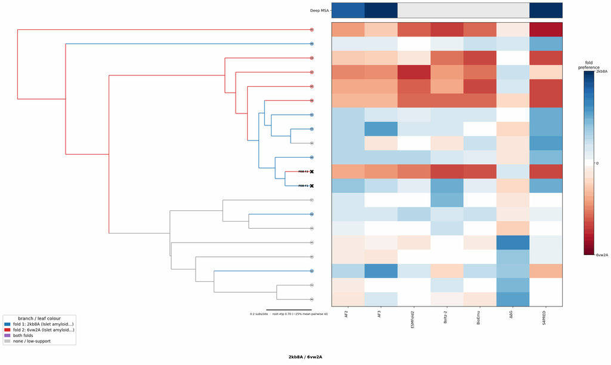

## Figure 2: Aligned overlay (both folds superposed)

The single fold-switching chain of each fold superposed by TM-align; waters hidden, any ligand shown as green sticks. Grey = structurally conserved core, colour = divergent (fold-switching) region. This pair switches fold coupled to oligomerisation; a single protomer is shown, not the full assembly.

2kb8A (Islet amyloid polypeptide) · monomer6vw2A (Islet amyloid polypeptide) · 10-mer

TM-score: 0.029 · Trigger class: oligomerization

Aligned overlay

Loading...

## Figure 3: The two folds, side by side

Each fold is coloured by per-residue Cα deviation between the two superposed structures: grey ≈ conserved core, full colour = structurally divergent (fold-switching) region.

2kb8A (Islet amyloid polypeptide)

6vw2A (Islet amyloid polypeptide)

0 Å5≥10 Å

2kb8A (Islet amyloid polypeptide)

Loading...

6vw2A (Islet amyloid polypeptide)

Loading...

## Figure 4: Best-cluster predicted contact maps over the two true folds.

Predicted contact maps (MSA-Transformer) for the clusters best matching each fold, over the true contacts of fold 1 (upper triangle) and fold 2 (lower). Divergent contacts between clusters are the contact-level signature of fold-switching.

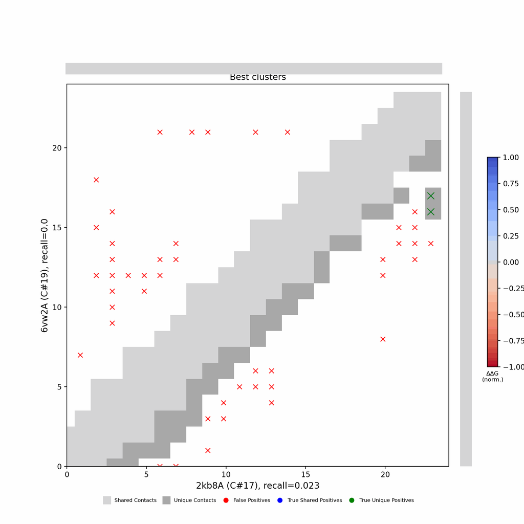

## Figure 5: Per-residue ΔΔG fold-preference contribution

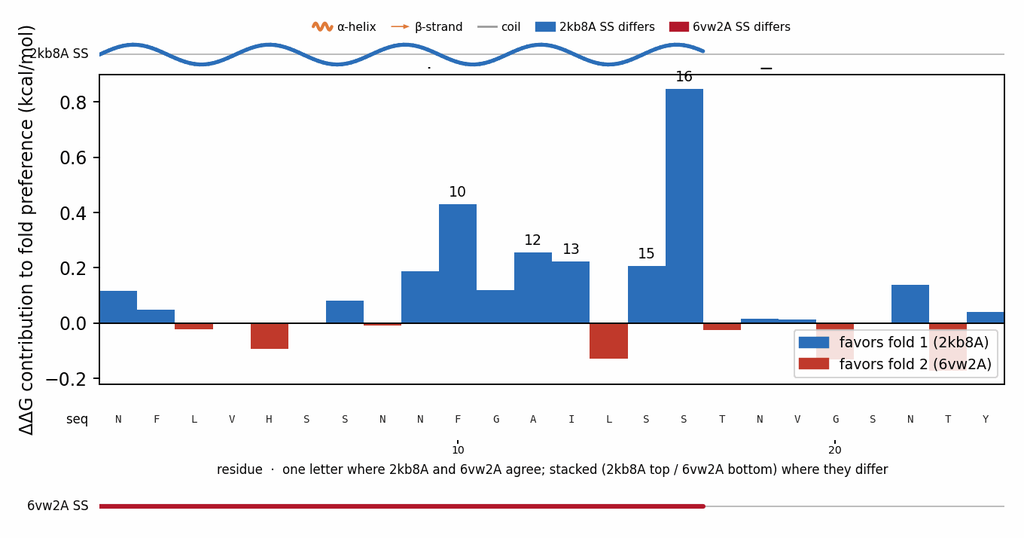

**More figures**

## Figure 6: Deep-MSA contact map panel / Best clusters contact map panel

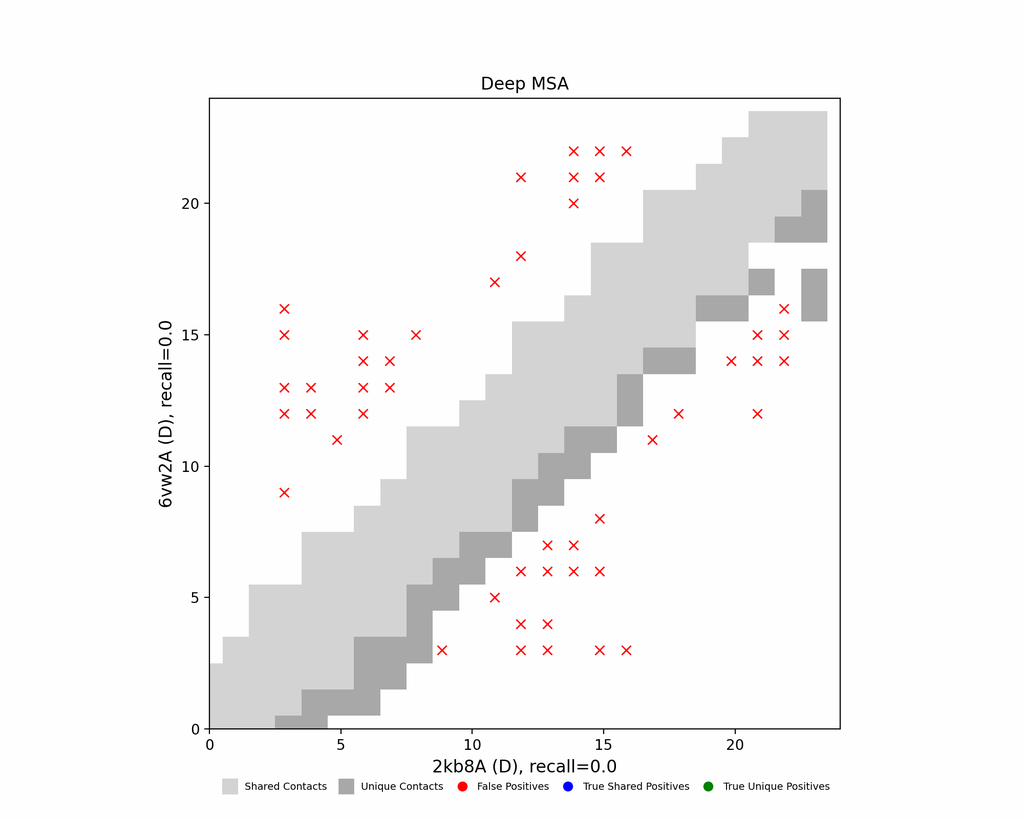

Deep-MSA contact map panel

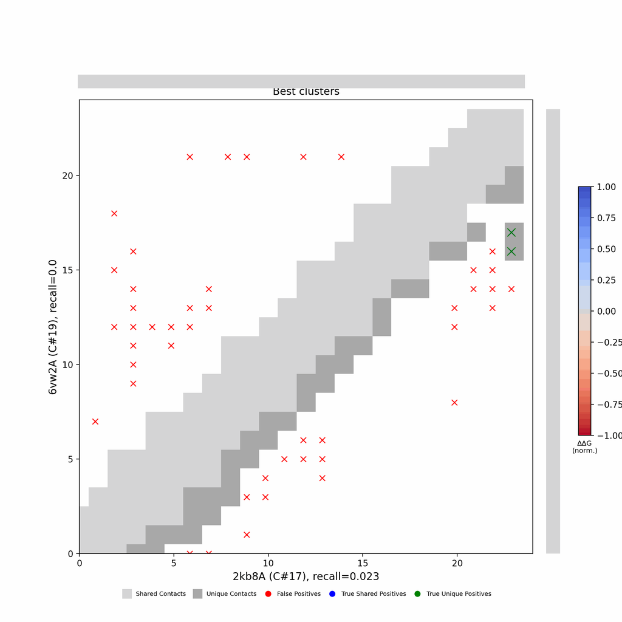

Best clusters contact map panel

## Figure 7: All clusters contact-map mosaic (small multiples).

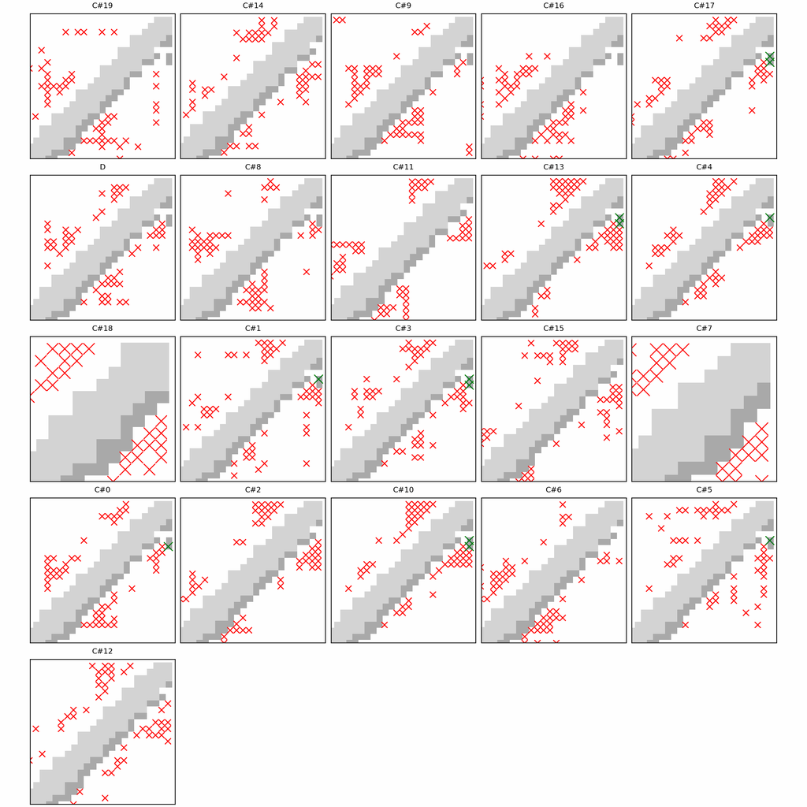

## Figure 8: Phylo null: tree with shuffled cluster fold labels.

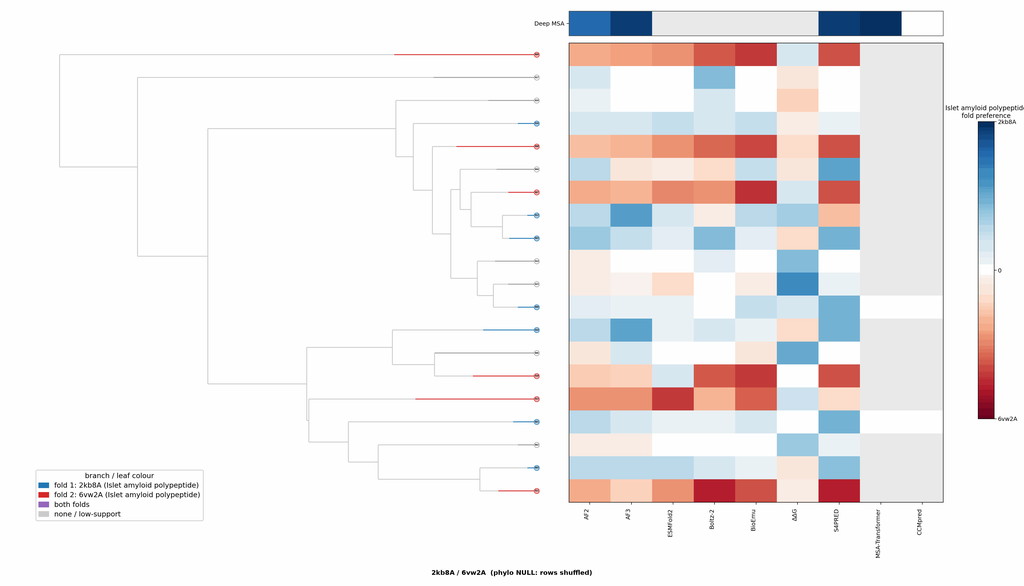

## Cluster metrics table

Per-cluster metrics underlying the figures above.

| cluster | n | neff | AF2_TM1 | AF2_TM2 | AF3_TM1 | AF3_TM2 | RE-MSAT-COM | RE-MSAT1 | RE-MSAT2 | ESM_SEQIDS | ESM_TM1 | ESM_TM2 | ΔΔG_Bias | ΔΔG_Bias_std | ΔΔG_frac_F1 | Boltz2_pref | S4PRED_pref | CCMpred_pref | BioEmu_pref |
| --- | --- | --- | --- | --- | --- | --- | --- | --- | --- | --- | --- | --- | --- | --- | --- | --- | --- | --- | --- |
| Deep | - | - | 0.56 | 0.21 | 0.6 | 0.17 | 0.0 | 0.03 | 0.0 | - | - | - | - | - | - | - | 0.43 | 0.0 | - |
| 000 | 120.0 | 12.0 | 0.51 | 0.17 | 0.37 | 0.13 | 0.0 | 0.03 | 0.0 | 008; 008; 003; 003; 006; 006; 009; 009; 002; 002 | 0.44 ± 0.05 | 0.14 ± 0.02 | 1.26 | 0.91 | 0.9 | 0.24 | 0.43 | 0.0 | 0.21 |
| 001 | 35.0 | 2.0 | 0.54 | 0.14 | 0.43 | 0.17 | 0.0 | 0.0 | 0.0 | 006; 006; 004; 004; 002; 002; 003; 003; 008; 008 | 0.44 ± 0.02 | 0.14 ± 0.02 | 0.9 | 0.31 | 1.0 | 0.27 | 0.43 | 0.0 | 0.2 |
| 002 | 33.0 | 5.0 | 0.45 | 0.2 | 0.33 | 0.17 | 0.0 | 0.06 | 0.0 | - | - | - | 1.91 | 0.17 | 1.0 | 0.22 | 0.24 | - | 0.17 |
| 003 | 31.0 | 1.0 | 0.6 | 0.14 | 0.5 | 0.18 | 0.0 | 0.0 | 0.0 | - | - | - | 0.52 | 0.38 | 0.8 | 0.4 | 0.43 | - | 0.19 |
| 004 | 26.0 | 1.0 | 0.57 | 0.16 | 0.38 | 0.23 | 0.0 | 0.0 | 0.0 | - | - | - | 0.62 | 0.44 | 1.0 | 0.17 | 0.46 | - | 0.21 |
| 005 | 26.0 | 4.0 | 0.59 | 0.18 | 0.47 | 0.15 | 0.0 | 0.05 | 0.0 | - | - | - | 0.67 | 0.34 | 1.0 | 0.28 | 0.4 | - | 0.18 |
| 006 | 26.0 | 1.0 | 0.42 | 0.17 | 0.41 | 0.13 | 0.0 | 0.0 | 0.0 | - | - | - | 2.25 | 0.3 | 1.0 | 0.2 | 0.2 | - | 0.14 |
| 007 | 24.0 | 10.0 | 0.28 | 0.16 | 0.18 | 0.13 | 0.0 | 0.0 | 0.0 | - | - | - | 1.36 | 0.43 | 1.0 | 0.07 | -0.08 | - | 0.03 |
| 008 | 24.0 | 5.0 | 0.27 | 0.11 | 0.22 | 0.17 | 0.0 | 0.08 | 0.0 | - | - | - | 0.47 | 0.37 | 1.0 | -0.0 | -0.08 | - | 0.05 |
| 009 | 24.0 | 9.0 | 0.29 | 0.17 | 0.17 | 0.16 | 0.0 | 0.0 | 0.0 | - | - | - | 1.37 | 0.6 | 0.9 | -0.04 | -0.08 | - | 0.04 |
| 010 | 24.0 | 1.0 | 0.55 | 0.13 | 0.57 | 0.13 | 0.0 | 0.03 | 0.0 | - | - | - | 0.45 | 0.21 | 0.9 | 0.29 | 0.43 | - | 0.18 |
| 011 | 23.0 | 4.0 | 0.3 | 0.18 | 0.23 | 0.13 | 0.0 | 0.0 | 0.0 | - | - | - | 0.74 | 0.53 | 0.8 | -0.05 | -0.14 | - | 0.05 |
| 012 | 23.0 | 2.0 | 0.58 | 0.18 | 0.62 | 0.16 | 0.0 | 0.0 | 0.0 | - | - | - | 1.83 | 0.32 | 1.0 | 0.14 | 0.08 | - | 0.22 |
| 013 | 21.0 | 1.0 | 0.25 | 0.16 | 0.19 | 0.19 | 0.0 | 0.03 | 0.0 | - | - | - | 1.49 | 0.38 | 1.0 | 0.06 | 0.12 | - | 0.06 |
| 014 | 21.0 | 1.0 | 0.39 | 0.13 | 0.38 | 0.18 | 0.0 | 0.0 | 0.0 | - | - | - | 2.04 | 0.3 | 1.0 | 0.27 | 0.2 | - | 0.17 |
| 015 | 21.0 | 10.0 | 0.41 | 0.14 | 0.38 | 0.19 | 0.0 | 0.08 | 0.0 | - | - | - | 2.56 | 0.58 | 1.0 | 0.2 | 0.25 | - | 0.15 |
| 016 | 16.0 | 9.0 | 0.51 | 0.14 | 0.44 | 0.17 | 0.0 | 0.0 | 0.0 | - | - | - | 0.78 | 0.61 | 0.9 | 0.29 | 0.24 | - | 0.21 |
| 017 | 16.0 | 7.0 | 0.51 | 0.13 | 0.36 | 0.15 | 0.0 | 0.03 | 0.0 | - | - | - | 0.62 | 0.76 | 0.7 | 0.38 | 0.2 | - | 0.18 |
| 018 | 14.0 | 6.0 | 0.36 | 0.18 | 0.2 | 0.1 | 0.0 | 0.04 | 0.0 | - | - | - | 1.01 | 0.67 | 1.0 | 0.01 | -0.08 | - | 0.03 |
| 019 | 14.0 | 1.0 | 0.46 | 0.14 | 0.42 | 0.2 | 0.0 | 0.08 | 0.0 | - | - | - | 0.37 | 0.3 | 0.9 | 0.3 | 0.22 | - | 0.17 |